# Name: Tanner Woods

# Question 1

```python
import numpy as np
import pandas as pd
import matplotlib.pyplot as plt
from datetime import datetime
import statsmodels.api as sm

# Setting seed
np.random.seed(1998)

# Importing excel file into pandas DataFrame
transactions = pd.read_csv("transactions.csv")
TRS = transactions["Sales_Amount"]
```

# Question 2

A) Log-likelihood of the exponential distribution: l($\lambda$|$Sales_{1}$,$Sales_{2}$,...,$Sales_{n}$) = n(ln($\lambda$)) - $\lambda$($\sum \limits_{j=1}^{n}$$Sales_{j}$)

B) (See below)

C) The $\lambda$ that maximizes the LLE function over the given range is $\lambda$ = 0.04.

D) (See below)

**Question 2B**

```python
# Lambda = (1/mean) for an exponential distribution.
# Alternatively, use "lambda_x = 1/transactions.Sales_Amount.mean()"
lambda_x = 1/TRS.mean()

# Defining function to compute log-likelihood of exp. dist. at a point
def log_likelihood_exponential(sales,lambda_value):
    LLE_output = np.log(lambda_value) - (lambda_value * sales)
    return(LLE_output)


# Defining function to compute log-likelihood of exp. dist. over a range
def log_likelihood_exponential_range(data, lambda_range):
    # Initializaing dataframe to store parameters and results
    frame_LLE = pd.DataFrame(columns = ["Likelihood","Lambda"])

    # For loop to perform LLE on each generated lambda parameter
    for i in lambda_range:
        result = log_likelihood_exponential(data,i).sum()

        # Append result to frame_LLE
        frame_LLE = frame_LLE.append({"Likelihood":result,"Lambda":i},ignore_index = True)

    return(frame_LLE)
```

```python
# Setting range of fifty random candidate parameters
lambdas = np.linspace(0,1,100, endpoint = False)

frame_LLE = log_likelihood_exponential_range(TRS,lambdas)
# frame_LLE
```

**Question 2C**

```python
# Finding maximizing row of values in "Likelihood" column
row_max = frame_LLE["Likelihood"].argmax()
frame_LLE.iloc[row_max]
```

```
Likelihood   -271324.870904
Lambda             0.040000
Name: 4, dtype: float64
```

**Question 2D**

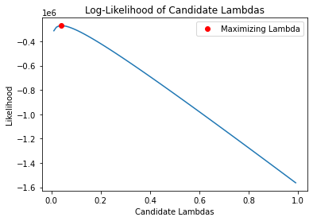

```python
plt.title("Log-Likelihood of Candidate Lambdas")
plt.plot(frame_LLE["Lambda"],frame_LLE["Likelihood"],label = "_nolegend_")
plt.xlabel("Candidate Lambdas")
plt.ylabel("Likelihood")
plt.plot(0.04,-271324.870904,"ro")
plt.legend(["Maximizing Lambda"])
```

# Question 3

A) $mpg_{median}$ = 19.2

B) (See below)

C) The standard error of the bootstrapped $mpg_{median}$ $\approx$ 1.2671

D) We can estimate with 95% confidence that the true population median is represented within the approximate interval of (16.779, 21.329)

**Question 3A**

```python
# Importing excel file into pandas DataFrame
mtcars = pd.read_csv("mtcars.csv")
# mtcars
```

```python
mpg = mtcars["mpg"]
mpg_median = mpg.median()
mpg_median
```

```
19.2
```

**Question 3B**

```python
# Performing 10000 samples w/ replacement to bootstrap medians in mtcars mpg
mpg_medians_boot = [np.median(np.random.choice(mpg, mtcars.shape[0])) for i in range(10000)]
# mpg_medians_boot
```

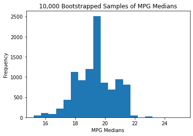

```python
plt.title("10,000 Bootstrapped Samples of MPG Medians")
plt.hist(mpg_medians_boot, bins = 20,label = "_nolegend_")
plt.xlabel("MPG Medians")
plt.ylabel("Frequency")
```

**Question 3C**

```python
mpg_boot_SE = np.std(mpg_medians_boot)
mpg_boot_SE
```

```
1.2670975415886496
```

**Question 3D**

```python
# Function from Professor Kunz's ECON 441A (Lecture 2, pg.9-10)
def empirical_ci(sample_median, boot_median, confidence):
    boot_means = np.array(boot_median).mean()
    differences = boot_median-boot_means

    alpha = (1-confidence)/2

    # Get the lower percentile confidence
    lower = np.percentile(differences, 100*alpha)

    # Get the upper percentile of confidence
    upper = np.percentile(differences, (1-alpha)*100)

    # Return gives me back a tuple of values
    return(lower+sample_median, upper+sample_median)
```

```python
empirical_ci(mpg_median, mpg_medians_boot, .95)
```

```
(16.778510000000004, 21.32851)
```

# Question 4

A) I chose to analyze the relationship between engine displacement and mpg. From my understanding, greater engine displacement loosely defines the power potential of an engine, which can lead to a higher potential fuel consumption.

B) (See below)

C) (See below)

D) The coefficient of 29.5999 for the constant informs us of predicted mpg at a theoretical engine displacement of 0; the respective p-value of 0 allows us to reject the $H_{0}$: $Constant$ = 0. Meanwhile, a coefficient -0.0412 for engine displacement describes the change in mpg for every marginal unit increase in engine displacement; the respective p-value of 0 allows us to reject the $H_{0}$: $Engine Displacement$ = 0.

Finally, the $R^{2}$ = 0.718 informs us that 71.8% of the variance within the data can be explained by the model.

**Question 4A**

```python
enginedisplace = mtcars["disp"]
# enginedisplace
```

**Question 4B**

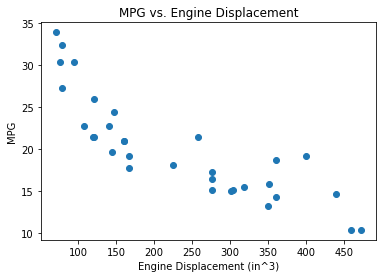

```python
plt.title("MPG vs. Engine Displacement")
plt.scatter(enginedisplace, mpg,label = "_nolegend_")
plt.xlabel("Engine Displacement (in^3)")
plt.ylabel("MPG")
```

**Question 4C**

```python
X = enginedisplace
X = sm.add_constant(X)
Y = mpg
mpgdisplacement_reg = sm.OLS(Y,X).fit()
mpgdisplacement_reg.summary()
```

OLS Regression Results

| Dep. Variable: | mpg | R-squared: | 0.718 |
| --- | --- | --- | --- |
| Model: | OLS | Adj. R-squared: | 0.709 |
| Method: | Least Squares | F-statistic: | 76.51 |
| Date: | Sun, 24 Oct 2021 | Prob (F-statistic): | 9.38e-10 |
| Time: | 18:24:19 | Log-Likelihood: | -82.105 |
| No. Observations: | 32 | AIC: | 168.2 |
| Df Residuals: | 30 | BIC: | 171.1 |
| Df Model: | 1 |  |  |
| Covariance Type: | nonrobust |  |  |

|  | coef | std err | t | P>\|t\| | [0.025 | 0.975] |
| --- | --- | --- | --- | --- | --- | --- |
| const | 29.5999 | 1.230 | 24.070 | 0.000 | 27.088 | 32.111 |
| disp | -0.0412 | 0.005 | -8.747 | 0.000 | -0.051 | -0.032 |

| Omnibus: | 3.368 | Durbin-Watson: | 1.250 |
| --- | --- | --- | --- |
| Prob(Omnibus): | 0.186 | Jarque-Bera (JB): | 3.049 |
| Skew: | 0.719 | Prob(JB): | 0.218 |
| Kurtosis: | 2.532 | Cond. No. | 558. |

Notes:  
[1] Standard Errors assume that the covariance matrix of the errors is correctly specified.

$MPG^{HAT}$ = 29.5999 - 0.0412($Engine Displacement$)